# Part II - Prosper Loan Data Presentation

## by Catherine Nwachukwu

## Investigation Overview

> The focus on the presentation will be for retired people and their distributions across the rating, borrowers rate and loan instalment. Effect of retirement on the prosper loan rating Monthly loan instalment for retired people Borrowers rate for retired people

## Dataset Overview

> The Prosper loan data set contains 113,937 loans with 81 variables on each loan, including Prosper Loan Rating, current loan status, borrowers occupation, employment status and many others. To have access to the dataset and data-dictionary, click on this link: [Udacity hosted dataset dataset](https://s3.amazonaws.com/udacity-hosted-downloads/ud651/prosperLoanData.csv)

## 1. Borrowers rate and Prosper rating for Retired Employees

> Borrowers rate for Retired Employees visualization is shown in a boxplot. Box plots are used to show overall patterns of Borrower's rating response to prosper rating group. They provide a useful way to visualise the range and other characteristics of responses for a large group.

> The diagram below shows a variety of different box plot shapes and positions.

```
[Text(0.5, 1.0, 'Borrowers rate of retired employers')]
```

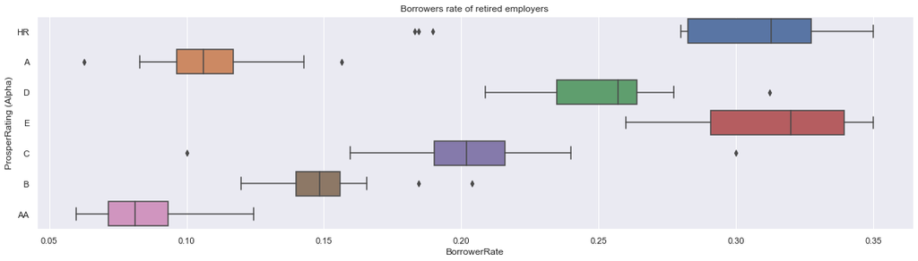

## Monthy loan payment of occupations for all employment status

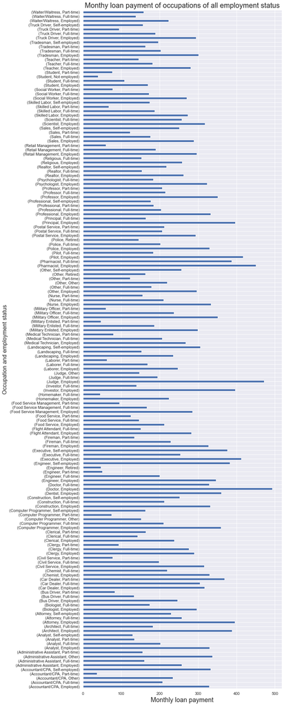

## Relationship between Loan duration and Prosper Rating

> Prosper rating 'HR' have maintained a consistent loan duration where as borrowers under group AA, A and D showed varied periods of loan duration.

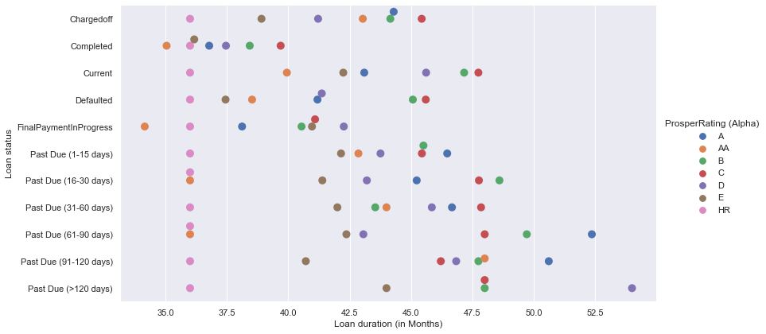